# Google Analytics Certificate Capstone Project

###### 22 January 2024

## Introduction

The purpose of this project is to demonstrate understanding of the skills learned in the [Google Data Analytics Professional Certificate courses](https://www.coursera.org/professional-certificates/google-data-analytics). We’ll use this [Champagne sales](https://www.kaggle.com/datasets/kankanashukla/champagne-data) dataset from kaggle.com (this looks like a duplicate, the brand may be*Perrin Freres*). We’ll walk through the six analysis steps: Ask, Prepare, Process, Analyze, Share, and Act.

My natural curiosity started me wondering when during the year sales spike. This being an older dataset, it’s also possible that trends have since changed. I’m interested to see whats there. I also like the challenge of doing a time series analysis without the normal tools (a trend line, most notably).

## Ask

Our business task her is to forecast upcoming champagne sales, with a specific eye toward any patterns around the time of year that might be helpful. This information is useful for executives in planning production, logistics, and even marketing.

## Process

The analysis will be done in R and in SQL. The R function *sqldf()* allows us to execute SQL statements on the data. The R T R libraries we’ll use for this are sqldf, tidyverse and skimr.

```r
library(sqldf)
library(skimr)
library(tidyverse)
library(lubridate)
```

It’s good to start by checking our data for errors, missing values, data types and so on. SkimR is my favorite for this.

```r
# Importing the dataset from .csv file to R DataFrameCallback
champagne_raw <- read.csv("champagne.csv")
# This will give us a sens of what the data looks like
glimpse(champagne_raw)
```

```
Rows: 105
Columns: 2
$ Month <chr> "1964-01", "1964-02", "1964-03", "1964-04", "196…
$ Sales <int> 2815, 2672, 2755, 2721, 2946, 3036, 2282, 2212, …
```

There’s the *Year_Month* format, and sales as integer values.

```r
# Will show us any missing values and some descriptive statistics
skim(champagne_raw)
```

```
── Data Summary ────────────────────────
                           Values
Name                       champagne_raw
Number of rows             105
Number of columns          2
_______________________
Column type frequency:
  character                1
  numeric                  1
________________________
Group variables            None
```

|  | skim_variable | n_missing | complete_rate | min | max | empty | n_unique | whitespace |
| --- | --- | --- | --- | --- | --- | --- | --- | --- |
| 1 | Month | 0 | 1 | 7 | 7 | 0 | 105 | 0 |

|  | skim_variable | n_missing | complete_rate | mean | sd | p0 | p25 | p50 | p75 | p100 | hist |
| --- | --- | --- | --- | --- | --- | --- | --- | --- | --- | --- | --- |
| 1 | Sales | 0 | 1 | 4761.152 | 2553.503 | 1413 | 3113 | 4217 | 5221 | 13916 | ▇▇▂▁▁ |

There are no missing or unusual values. But, that *Month* column will take some work to get it into a timeline, with separate columns for year and month.Let’s start there.

```r
champagne_clean <- champagne_raw
champagne_clean <-rename(champagne_clean, c("old_month"="Month"))
champagne_clean <- sqldf(
    "WITH clean AS (
    SELECT
      RANK() OVER(ORDER BY old_month) AS Timeline,
      CAST(Leftstr(old_month, 4) AS Int) AS Year,
      CAST(Rightstr(old_month,2) AS Int) AS Month,
      Sales


      FROM champagne_clean
      ORDER BY Timeline
      )

SELECT *
FROM Clean

  ")
champagne_clean
```

| Timeline | Year | Month | Sales |
| --- | --- | --- | --- |
| 1 | 1964 | 1 | 2815 |
| 2 | 1964 | 2 | 2672 |
| 3 | 1964 | 3 | 2755 |
| 4 | 1964 | 4 | 2721 |
| 5 | 1964 | 5 | 2946 |
| 6 | 1964 | 6 | 3036 |
| 7 | 1964 | 7 | 2282 |
| 8 | 1964 | 8 | 2212 |
| 9 | 1964 | 9 | 2922 |
| 10 | 1964 | 10 | 4301 |

[output cut: 95 more lines]

```r
NA
```

Here’s a list of what the above SQL accomplished:

**Changes:**

- Added a *Timeline* column
- Column *Month* was split into *Year* and *Month*
- Both *Year* and *Month* were converted to integer types

## Analyze

Our first task is to split our data into a training set and a test set. When we evluate a model’s performance, we want to see how it works against data it hasn’t seen before.

```r
champagne_train <- sqldf("
                         SELECT *
                         FROM champagne_clean
                         WHERE Year < 1969
                         ")
champagne_test <- sqldf("
                         SELECT *
                         FROM champagne_clean
                         WHERE Year > 1968
                         ")
```

A time series can often be broken into three component parts: *Trend* is the general movement upward or downward over time. *Seasonality* is the regular uptick or downtick, at a fixed interval. For example, U.S. retail sales surge in December and dip in February. *Noise* is the natural variation that cannot be captured by a pattern in the data.

Using a decomposition model, we’ll be able to look for these components. This model has the benefit of being simple to understand and explain, making it more transparent.

```r
# Calculating median annual sales in first four years
x <- sqldf("
            SELECT MEDIAN(Sales) AS Sales
           FROM champagne_train
           WHERE Year <= 1967
           GROUP BY Year
           ")
# Calculating median annual sales in second through fifth years
y <- sqldf("
           SELECT MEDIAN(Sales) AS Sales
           FROM champagne_train
           WHERE Year BETWEEN 1965 AND 1968
           GROUP BY Year
           ")
# Taking the average year over year difference
z <- mean(y$Sales - x$Sales) / 12
# Finding the starting point of the trendline
b <- sqldf("
           SELECT MEDIAN(Sales)
           FROM champagne_train
           WHERE Year = 1964
           GROUP BY Year
           ")
b <- b - (z * 6)
paste("Intercept: ", b)
```

```
[1] "Intercept:  2668.375"
```

```r
paste("Slope: ", z)
```

```
[1] "Slope:  33.3541666666667"
```

The code below teases apart the different components of the time series. Trend is the trend component; DeTrend is the data without the trend part.

```r
champagne_train <- sqldf("
                         SELECT *, (Timeline *33.4 + 2668) AS Trend
                         FROM champagne_train
                         ")

champagne_train <- sqldf("
                         SELECT *, (Sales / Trend) DeTrend
                         FROM champagne_train
                         ")
champagne_train <- sqldf("
                          WITH Season AS
                          (SELECT Month, MEDIAN(DeTrend) Seas
                          FROM champagne_train
                          GROUP BY Month
                          )

                         SELECT Timeline, Year, champagne_train.Month, Sales, Trend, DeTrend, Seas, (DeTrend / Seas) DeSeas
                         FROM champagne_train
                         LEFT JOIN Season

                         ON champagne_train.Month = season.Month

                         ")

champagne_train
```

| Timeline | Year | Month | Sales | Trend | DeTrend | Seas | DeSeas |
| --- | --- | --- | --- | --- | --- | --- | --- |
| 1 | 1964 | 1 | 2815 | 2701.4 | 1.0420523 | 0.8886669 | 1.1726017 |
| 2 | 1964 | 2 | 2672 | 2734.8 | 0.9770367 | 0.8500170 | 1.1494320 |
| 3 | 1964 | 3 | 2755 | 2768.2 | 0.9952316 | 0.9564531 | 1.0405440 |
| 4 | 1964 | 4 | 2721 | 2801.6 | 0.9712307 | 0.9777420 | 0.9933405 |
| 5 | 1964 | 5 | 2946 | 2835.0 | 1.0391534 | 1.0826046 | 0.9598642 |
| 6 | 1964 | 6 | 3036 | 2868.4 | 1.0584298 | 1.0629305 | 0.9957658 |
| 7 | 1964 | 7 | 2282 | 2901.8 | 0.7864084 | 0.8802722 | 0.8933696 |
| 8 | 1964 | 8 | 2212 | 2935.2 | 0.7536113 | 0.4209484 | 1.7902701 |
| 9 | 1964 | 9 | 2922 | 2968.6 | 0.9843024 | 1.0669555 | 0.9225336 |
| 10 | 1964 | 10 | 4301 | 3002.0 | 1.4327115 | 1.3700179 | 1.0457612 |

[output cut: 50 more lines]

The last column, the deSeasonalized data, should be stationary. That is, it should look random, showing no pattern or relationship to time. Let’s spot check it. This variable also makes it easy to spot outliers.

```r
champagne_season <- sqldf("
                          SELECT Month,
                          Avg(DeTrend) as Avg_Seasonal,
                          MEDIAN(DeTrend) AS Median_Seasonal
                          FROM champagne_train
                          GrOUP BY Month
                          ")

print(as_tibble(champagne_season), n = 12)
```

| Month | Avg_Seasonal | Median_Seasonal |
| --- | --- | --- |
| 1 | 0.9941319 | 0.8886669 |
| 2 | 0.8780172 | 0.8500170 |
| 3 | 0.9944023 | 0.9564531 |
| 4 | 1.0063552 | 0.9777420 |
| 5 | 1.0910563 | 1.0826046 |
| 6 | 1.0620975 | 1.0629305 |
| 7 | 0.8712335 | 0.8802722 |
| 8 | 0.4957154 | 0.4209484 |
| 9 | 1.0454712 | 1.0669555 |
| 10 | 1.3823282 | 1.3700179 |

[output cut: 2 more lines]

This seasonal pattern is pretty close to what I expected. The early part of the year has little seasonal effect, with a small bump in September. October jumps, November is higher still, and December sees peek sales over a year.

In summary:

- Trend has been removed
- Seasonality has been removed
- Seasonality has been aggregated for analysis and future use
- Sales, without these moving parts, allow us to see more easily how much variance we have, and which years were abnormally high or low.

## Share

There’s a clear, year over year upward trend in sales.

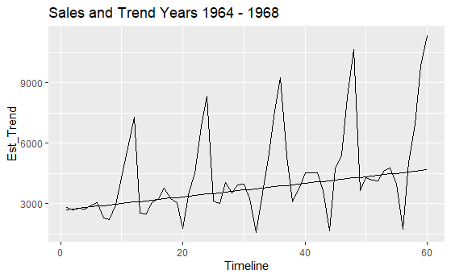

```r
# Training data with trend
ggplot(champagne_ts) +
geom_line(mapping=aes(y=Est_Trend, x=Timeline))+
geom_line(mapping=aes(y=Sales, x=Timeline)) +
labs(title= "Sales and Trend Years 1964 - 1968")
```

Int terms of seasonality, - January through July are roughly equal to the year’s average - August dips significantly, being around half the year’s average - September sees a small bump, with October, November and December each increasing over the previous month.

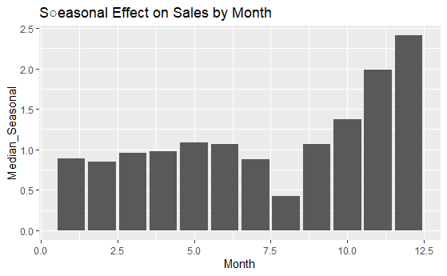

```r
# Plot of seasonal effects
ggplot(champagne_season) +
geom_col(mapping=aes(y=Median_Seasonal, x=Month)) +
  labs(title="S○easonal Effect on Sales by Month")
```

There are two significant outliers, each above 1.4 on the chart (40% above the year’s average sales). These two points are candidates to be removed and replaced by a seasonally normal value, unless we expect to see points like those in the future.

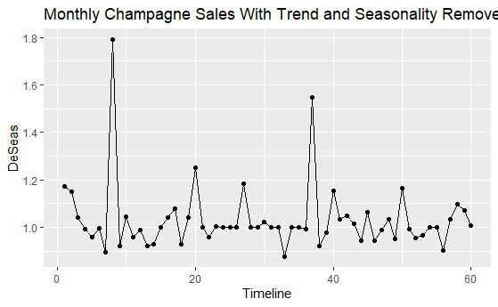

```r
# Stationary data, for outlier detection
ggplot(champagne_train) +
  geom_line(mapping=aes(y=DeSeas, x=Timeline)) +
  geom_point(mapping=aes(y=DeSeas, x=Timeline)) +
  labs(title= "Monthly Champagne Sales With Trend and Seasonality Removed")
```

## Act

Additionally, we could examine:

- Historical advertising records, looking for correlations between media type, timing, audience, etc and sales.
- Historical headcount data by department to look for staffing capacity gaps.
- Historical warehouse levels and shipping costs to look for savings opportunities.

## Conclusion

That was interesting. We used R and SQL to decompose this dataset of champagne sales. I’d bet that October through December mark the ramp-up to the holiday season. The August lull is very interesting. I’d guess it’s either to do with the culture of summer vacations in Europe, or it’s something unique to the company. Since it’s the 1960’s, I’d bet the former.

Thanks for taking this journey with me. It’s been fun!